# Assignment 11

MJKelleher

March 26, 2018

## 1) Warm Up: Brief Financial Data

### (a.) Investigate the DAX Index from the EuStockMarkets Object built into R. Use only the DAX index.

```r
# EU Stock Data 1990 - 1999
#
str(EuStockMarkets)
```

```
##  Time-Series [1:1860, 1:4] from 1991 to 1999: 1629 1614 1607 1621 1618 ...
##  - attr(*, "dimnames")=List of 2
##   ..$ : NULL
##   ..$ : chr [1:4] "DAX" "SMI" "CAC" "FTSE"
```

```r
head(EuStockMarkets)
```

```
## Time Series:
## Start = c(1991, 130)
## End = c(1991, 135)
## Frequency = 260
##              DAX    SMI    CAC   FTSE
## 1991.496 1628.75 1678.1 1772.8 2443.6
## 1991.500 1613.63 1688.5 1750.5 2460.2
## 1991.504 1606.51 1678.6 1718.0 2448.2
## 1991.508 1621.04 1684.1 1708.1 2470.4
## 1991.512 1618.16 1686.6 1723.1 2484.7
## 1991.515 1610.61 1671.6 1714.3 2466.8
```

```r
# German Stock Exchange
#
dax <- EuStockMarkets[,1]
```

### (b.) Create a rudimentary plot in blue with properly labeled axes, and appropriate title. Add vertical red line at 1997.

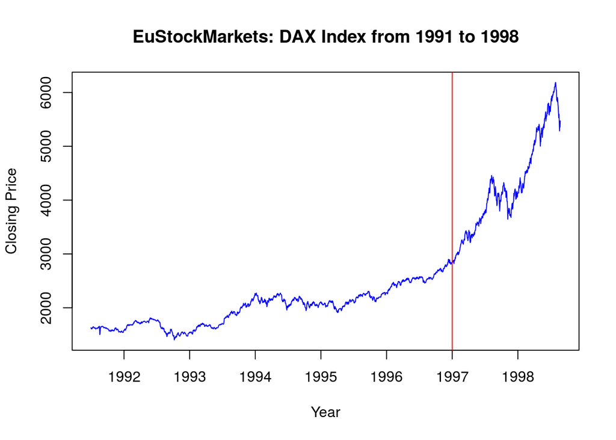

```r
# Plot the time-series data
plot(dax, xlab="Year", ylab="Closing Price", main="EuStockMarkets: DAX Index from 1991 to 1998", col="blue")

# Add plot at 1997
abline(v=1997, col="red")
```

### (c.) Decompose the timeseries into its components, using a mul;tiplicative model. Create plots for all decomposed components, blue lines and red divider at 1997.

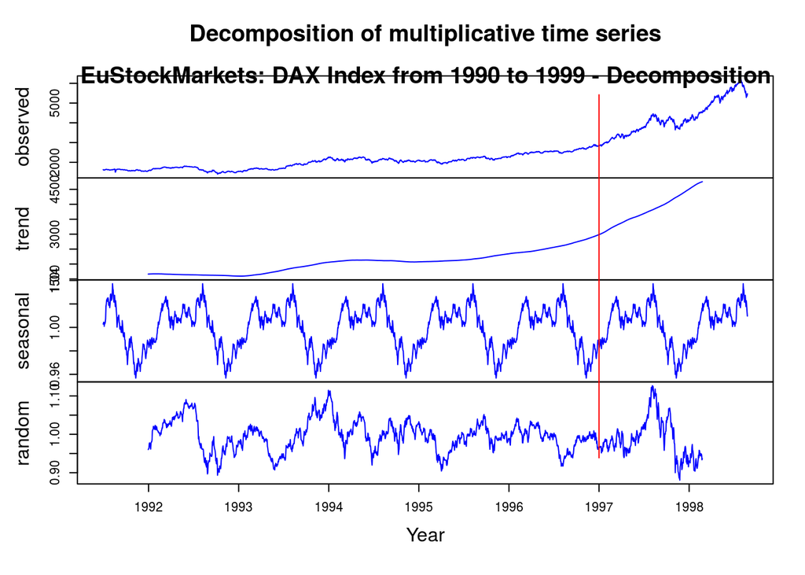

```r
# https://a-little-book-of-r-for-time-series.readthedocs.io/en/latest/src/timeseries.html#decomposing-seasonal-data

#sesfit <- ses(dax, alpha=0.8, initial="simple", exponential=TRUE, h=10)
#holtfit <- holt(dax, alpha=0.8, beta=0.2, initial="simple", exponential=TRUE, h=10)
#hwfit <- hw(dax, seasonal="multiplicative", initial="simple")

comps <- decompose(dax, type = "multiplicative" )

plot(comps, xlab="Year", col="blue")

title("\n\nEuStockMarkets: DAX Index from 1990 to 1999 - Decomposition")

abline(v=1997, col="red")
```

## 2) Temperature Data

### (a.) Using the maxtemp dataset granted by loading fpp2, there are maximum annual temperature data in Celsius. For more information, use help(maxtemp). To see what you’re looking at, execute the command in ‘Examples’ in the help document.

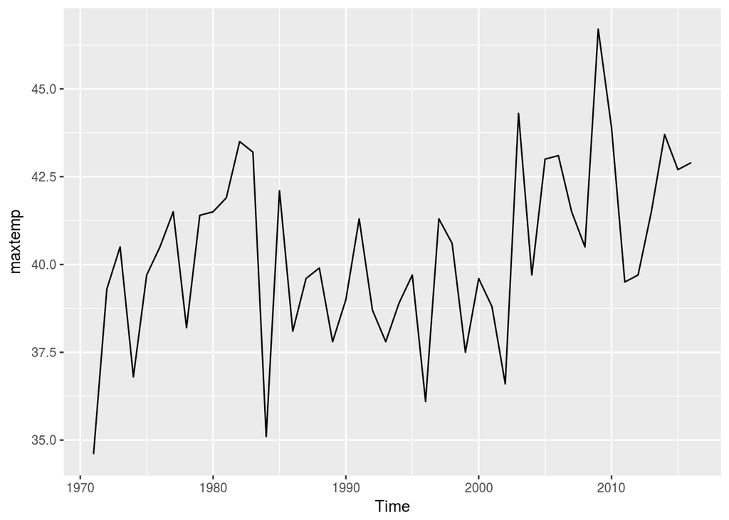

```r
help(maxtemp)

autoplot(maxtemp)
```

### (b.) We are only concerned with information after 1990. Please eliminate unwanted information or subset information we care about.

```r
# Subset the timeseries on its column name, taking only 1991 and later
# http://stat.ethz.ch/R-manual/R-devel/library/base/html/names.html
# https://www.r-bloggers.com/extracting-information-from-objects-using-names/

# This ends up being a "numeric" and not a "ts"
# mxtemp_post_1990 <- maxtemp[names(maxtemp) > "1990"]
maxtemp_post_1990 <- window(maxtemp,start=1991,end=2016)
```

### (c.) Melbourne Prediction

#### Utilize SES to predict the next five years of maximum temperatures in Melbourne. Plot this information, including the prior information and the forecast. Add the predicted value line across 1990-present as a separate line, preferably blue.

#### So, to review, you should have: (all on one axis.)

- your fit
- the predicted value line overlaying it (1990-present) in blue
- and a forecast 2017 through 2021
- ALSO: Find the AICc of this fitted model. You will use that information later.

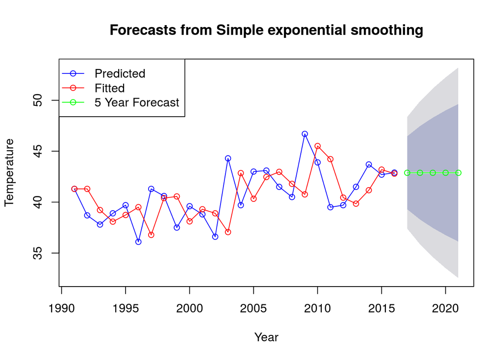

```r
maxtemp_ses_post_1990_5_yr <- ses(maxtemp_post_1990, alpha=0.8, initial="simple", exponential=TRUE, h=5)

# The Predicted Values
plot(maxtemp_ses_post_1990_5_yr, ylab="Temperature", xlab="Year", fcol="white", type="o", col="blue")

# The Fitted Values
fit_maxtemp_ses_post_1990_5_yr <- fitted(maxtemp_ses_post_1990_5_yr)
lines(fit_maxtemp_ses_post_1990_5_yr, col="red", type="o")

# The Forecasted Values
lines(maxtemp_ses_post_1990_5_yr$mean, col="green", type="o")

legend("topleft", lty=1, col=c("blue", "red", "green"), c("Predicted", "Fitted", "5 Year Forecast"), pch=1)
```

```r
# https://robjhyndman.com/talks/MelbourneRUG.pdf   On Page 80  mentions AICc
#
# https://www.rdocumentation.org/packages/MuMIn/versions/1.40.0/topics/AICc
#
# https://www.rdocumentation.org/packages/AICcmodavg/versions/2.1-1
# https://www.rdocumentation.org/packages/AICcmodavg/versions/2.1-1/topics/AICc
#
# https://stats.stackexchange.com/questions/19542/how-do-i-get-the-aic-value-out-from-a-forecast-object-in-r

# I have NO idea what this is actually doing, but it gives me a value....
#
aic_fit_maxtemp_ses_post_1990_5_yr <- AICc(ets(fit_maxtemp_ses_post_1990_5_yr))
aic_fit_maxtemp_ses_post_1990_5_yr
```

```
## [1] 126.0518
```

### (d.) Now use a damped Holt’s linear trend to also predict out five years. Make sure initial=“optimal.” As above, create a similar plot to 1C, but use the Holt fit instead.

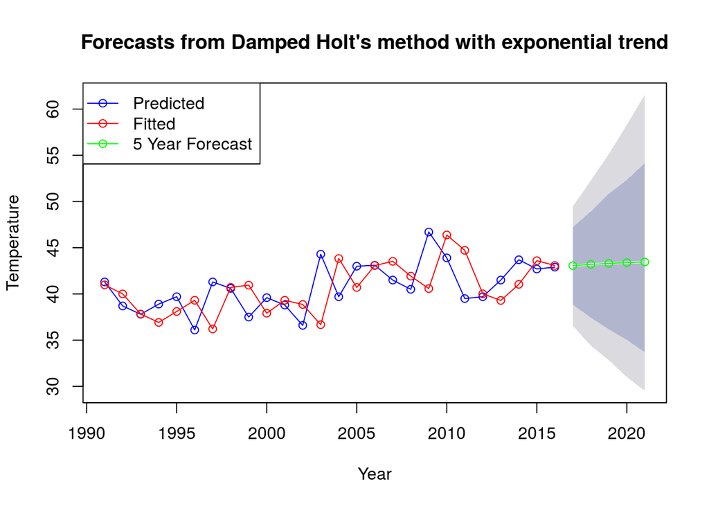

```r
holt_maxtemp_post_1990_5_yr <- holt(maxtemp_post_1990, initial="optimal", alpha=0.8, beta=0.2, damped=TRUE, exponential=TRUE, h=5)

# The Predicted Values
plot(holt_maxtemp_post_1990_5_yr, ylab="Temperature", xlab="Year", fcol="white", type="o", col="blue")

# The Fitted Values
holt_fit_maxtemp_post_1990_5_yr <- fitted(holt_maxtemp_post_1990_5_yr)
lines(holt_fit_maxtemp_post_1990_5_yr, col="red", type="o")

# The Forecasted Values
lines(holt_maxtemp_post_1990_5_yr$mean, col="green", type="o")

legend("topleft", lty=1, col=c("blue", "red", "green"), c("Predicted", "Fitted", "5 Year Forecast"), pch=1)
```

```r
# I have NO idea what this is actually doing, but it gives me a value....
#
aic_holt_fit_maxtemp_post_1990_5_yr <- AICc(ets(holt_fit_maxtemp_post_1990_5_yr))
aic_holt_fit_maxtemp_post_1990_5_yr
```

```
## [1] 135.9813
```

### (e) Compare the AICc of the ses() and holt() models. Which model is better here?

Based on the info from [Wikipedia on AICc](https://en.wikipedia.org/wiki/Akaike_information_criterion), the one with the smaller value is the better fitting model. Thus, the SES model is the better model.

## 3) The Wands Choose the Wizard

### (a.) Utilize the dygraphs library. Read in both Unit11TimeSeries_Ollivander and _Gregorovitch.csv as two different data frames. They do not have headers, so make sure you account for that. This is a time series of Wands sold over years.

```r
filename <- "Unit11TimeSeries_Gregorovitch.csv"
dataURL <- paste(dbxroot, filename, sep="")
gregorovitch <- read.csv(url(dataURL), header=FALSE)
names(gregorovitch) <- c("SYear", "NumSold")
gregorovitch$SYear <- trimws(as.character(gregorovitch$SYear))

filename <- "Unit11TimeSeries_Ollivander.csv"
dataURL <- paste(dbxroot, filename, sep="")
ollivander <- read.csv(url(dataURL), header=FALSE)
names(ollivander) <- c("SYear", "NumSold")
ollivander$SYear <- trimws(as.character(ollivander$SYear))
```

### (b.) You don’t have your information in the proper format! In both data sets, you’ll need to first convert the date-like variable to an actual Date class

```r
gregorovitch$Year <- as.Date(gregorovitch$SYear, "%m/%d/%Y")
# gregorovitch[c("SYear")] <- list(NULL)

ollivander$Year <- as.Date(ollivander$SYear, "%m/%d/%Y")
# ollivander[c("SYear")] <- list(NULL)
```

### (c.) Use the library xts (and the xts() function in it) to make each data frame an xts object (effectively, a time series). You’ll want to order.by the Date variable.

```r
xts_greg <- as.xts(x=gregorovitch, order.by = gregorovitch$Year)
# xts_greg <- xts_greg[,colnames(xts_greg) != "Year"]

xts_oll <- as.xts(x=ollivander, order.by = ollivander$Year)
# xts_oll <- xts_oll[,colnames(xts_oll) != "Year"]
```

### (d.) Bind the two xts objects together and create a dygraph from it.

- Give an effective title and x/y axes.
- Label each Series (via dySeries) to be the appropriate wand-maker. So, one line should create a label for Ollivander and the other for Gregorovitch.
- Stack this graph and modify the two lines to be different colors (and not the default ones!) Any colors are fine, but make sure they’re visible and that Ollivander is a different color than Gregorovitch.
- Activate a range selector and make it big enough to view.
- Use dyShading to illuminate approximately when Voldemort was revived and at-large: between 1995 to 1999.
- Enable Highlighting on the graph, so mousing over a line bolds it.

```r
# colnames(xts_greg) <- c("SYear", "NumSoldGreg", "Year")
# colnames(xts_oll) <- c("SYear", "NumSoldOll", "Year")

# Create a dataframe to merge the data properly and then create an xts Object
#
df_temp <- data.frame(gregorovitch$Year, ollivander$Year, gregorovitch$NumSold, ollivander$NumSold)
names(df_temp) <- c("Year", "OYear", "GregNumSold", "OllNumSold")

# Get the Max Y Value
m1 <- max(df_temp$GregNumSold)
m2 <- max(df_temp$OllNumSold)
ymax <- max(c(m1, m2)) + 200

# Cross check/verify to make sure the rows match up
#
allEqual <- sum(df_temp$Year == df_temp$OYear)
missing <- sum(df_temp$Year != df_temp$OYear)

sprintf("Number rows with equal Date: %d, Number rows with unequal Date: %d", allEqual, missing)
```

```
## [1] "Number rows with equal Date: 48, Number rows with unequal Date: 0"
```

```r
# Get the min and Max for the date range window
#
dateMin <- min(df_temp$Year)
dateMax <- max(df_temp$Year)


# Remove the Year Columns now that we have verified everything is OK
#
xts_temp <- as.xts(x=df_temp, order.by = df_temp$Year)
xts_temp <- xts_temp[,colnames(xts_temp) != "Year"]
xts_temp <- xts_temp[,colnames(xts_temp) != "OYear"]


# None of these worked in merging the 2 xts Objects
# xts_temp <- rbind(xts_greg, xts_greg)
# merge(xts_temp, xts_greg, by="SYear")

# https://rstudio.github.io/dygraphs/
# https://rpubs.com/mohammadshadan/288218

# Now plot the dygraph
#
dygraph(xts_temp, main="Number of Wands Sold by Year", group="OllNumSold") %>%
    dySeries("GregNumSold", label = "Gregorovitch", color="DarkGreen") %>%
    dySeries("OllNumSold", label = "Ollivander", color="Orange") %>%
    dyAxis("y", valueRange = c(0, ymax)) %>%
    dyShading(from = "1995-1-1", to = "1999-1-1") %>%
    dyHighlight(highlightCircleSize = 5, highlightSeriesBackgroundAlpha = 0.2, hideOnMouseOut = FALSE) %>%
    dyOptions(stackedGraph = FALSE, fillGraph=FALSE, fillAlpha = 0.0, drawPoints=TRUE, pointSize=3) %>%
    dyRangeSelector(height = 20, dateWindow = c(dateMin, dateMax))
```

[interactive chart not shown]